# Multiple Regression

February 21, 2018

## Back to the CDC dataset!!

Predict height based on smoke100, how do we interpret the slope?

```r
cdc %>% lm(height~smoke100, data=.) %>% summary()
```

```
##
## Call:
## lm(formula = height ~ smoke100, data = .)
##
## Residuals:
##      Min       1Q   Median       3Q      Max
## -19.5365  -2.8667  -0.2016   3.1333  26.1333
##
## Coefficients:
##             Estimate Std. Error t value Pr(>|t|)
## (Intercept) 66.86675    0.04002  1670.8   <2e-16 ***
## smoke100     0.66974    0.05825    11.5   <2e-16 ***
## ---
## Signif. codes:  0 '***' 0.001 '**' 0.01 '*' 0.05 '.' 0.1 ' ' 1
##
## Residual standard error: 4.112 on 19998 degrees of freedom
## Multiple R-squared:  0.006567,   Adjusted R-squared:  0.006517
## F-statistic: 132.2 on 1 and 19998 DF,  p-value: < 2.2e-16
```

## Another model: predict height by exerany

```r
cdc %>% lm(height~exerany, data=.) %>% summary()
```

```
##
## Call:
## lm(formula = height ~ exerany, data = .)
##
## Residuals:
##      Min       1Q   Median       3Q      Max
## -19.4539  -3.3883  -0.3883   3.5461  25.5461
##
## Coefficients:
##             Estimate Std. Error t value Pr(>|t|)
## (Intercept) 66.38832    0.05749 1154.81   <2e-16 ***
## exerany      1.06555    0.06657   16.01   <2e-16 ***
## ---
## Signif. codes:  0 '***' 0.001 '**' 0.01 '*' 0.05 '.' 0.1 ' ' 1
##
## Residual standard error: 4.1 on 19998 degrees of freedom
## Multiple R-squared:  0.01265,    Adjusted R-squared:  0.0126
## F-statistic: 256.2 on 1 and 19998 DF,  p-value: < 2.2e-16
```

## Form of the model

Note: this is a model for the population (no hats!):

\[\mu_Y = \beta_0 + \beta_1 X_1 +\beta_2 X_2 + \ldots + \beta_k X_k\]

\[Y = \beta_0 + \beta_1 X_1 +\beta_2 X_2 + \ldots + \beta_k X_k + \epsilon\]

What’s the difference?

## How to run it

What is the equation for the line of best fit?

```r
cdc %>% lm(height~exerany+smoke100, data=.) %>% summary()
```

```
##
## Call:
## lm(formula = height ~ exerany + smoke100, data = .)
##
## Residuals:
##      Min       1Q   Median       3Q      Max
## -19.8306  -3.1297  -0.1297   3.1694  25.8703
##
## Coefficients:
##             Estimate Std. Error t value Pr(>|t|)
## (Intercept) 66.03788    0.06418 1028.96   <2e-16 ***
## exerany      1.09182    0.06637   16.45   <2e-16 ***
## smoke100     0.70088    0.05789   12.11   <2e-16 ***
## ---
## Signif. codes:  0 '***' 0.001 '**' 0.01 '*' 0.05 '.' 0.1 ' ' 1
##
## Residual standard error: 4.085 on 19997 degrees of freedom
## Multiple R-squared:  0.01983,    Adjusted R-squared:  0.01973
## F-statistic: 202.3 on 2 and 19997 DF,  p-value: < 2.2e-16
```

## The new anova table

Check df - we now have 2 degrees taken up by the predictors, so we’ve got \(n-2-1\) for the df of the residuals. (How many values are we predicting from our model?)

```r
cdc %>% lm(height~exerany+smoke100, data=.) %>% anova()
```

```
## Analysis of Variance Table
##
## Response: height
##              Df Sum Sq Mean Sq F value    Pr(>F)
## exerany       1   4306  4306.1  258.04 < 2.2e-16 ***
## smoke100      1   2446  2445.9  146.57 < 2.2e-16 ***
## Residuals 19997 333701    16.7
## ---
## Signif. codes:  0 '***' 0.001 '**' 0.01 '*' 0.05 '.' 0.1 ' ' 1
```

## The new standard error of the multiple regression model:

\[\hat{\sigma_\epsilon} = \sqrt{\frac{SSE}{df}} = \sqrt{\frac{SSE}{n-k-1}}\]

where we have \(k\) predictors.

## More multivarite models

How do we interpret these coefficients? What is the equation of the regression line?

```r
cdc %>% lm(height~age+exerany, data=.) %>% summary()
```

```
##
## Call:
## lm(formula = height ~ age + exerany, data = .)
##
## Residuals:
##      Min       1Q   Median       3Q      Max
## -19.9016  -3.0774  -0.1793   3.1191  25.1816
##
## Coefficients:
##              Estimate Std. Error t value Pr(>|t|)
## (Intercept) 67.715867   0.098654   686.4   <2e-16 ***
## age         -0.027761   0.001682   -16.5   <2e-16 ***
## exerany      0.963094   0.066417    14.5   <2e-16 ***
## ---
## Signif. codes:  0 '***' 0.001 '**' 0.01 '*' 0.05 '.' 0.1 ' ' 1
##
## Residual standard error: 4.072 on 19997 degrees of freedom
## Multiple R-squared:  0.02591,    Adjusted R-squared:  0.02582
## F-statistic:   266 on 2 and 19997 DF,  p-value: < 2.2e-16
```

## One more model

```r
cdc %>% lm(height~age+weight, data=.) %>% summary()
```

```
##
## Call:
## lm(formula = height ~ age + weight, data = .)
##
## Residuals:
##      Min       1Q   Median       3Q      Max
## -17.4194  -2.2439   0.0798   2.3813  24.8586
##
## Coefficients:
##               Estimate Std. Error t value Pr(>|t|)
## (Intercept) 58.8429936  0.1217266  483.40   <2e-16 ***
## age         -0.0302560  0.0013950  -21.69   <2e-16 ***
## weight       0.0571860  0.0005984   95.57   <2e-16 ***
## ---
## Signif. codes:  0 '***' 0.001 '**' 0.01 '*' 0.05 '.' 0.1 ' ' 1
##
## Residual standard error: 3.392 on 19997 degrees of freedom
## Multiple R-squared:  0.3243, Adjusted R-squared:  0.3242
## F-statistic:  4798 on 2 and 19997 DF,  p-value: < 2.2e-16
```

## Age and weight

Is this the same as weight=0?

```r
cdc %>% lm(height~age, data=.) %>% summary()
```

```
##
## Call:
## lm(formula = height ~ age, data = .)
##
## Residuals:
##     Min      1Q  Median      3Q     Max
## -19.696  -3.125  -0.245   3.146  25.395
##
## Coefficients:
##              Estimate Std. Error t value Pr(>|t|)
## (Intercept) 68.536818   0.081214  843.91   <2e-16 ***
## age         -0.030042   0.001684  -17.84   <2e-16 ***
## ---
## Signif. codes:  0 '***' 0.001 '**' 0.01 '*' 0.05 '.' 0.1 ' ' 1
##
## Residual standard error: 4.094 on 19998 degrees of freedom
## Multiple R-squared:  0.01567,    Adjusted R-squared:  0.01562
## F-statistic: 318.4 on 1 and 19998 DF,  p-value: < 2.2e-16
```

## Correlation in the predictors

```r
cor.test(cdc$age, cdc$weight)
```

```
##
##  Pearson's product-moment correlation
##
## data:  cdc$age and cdc$weight
## t = 0.22752, df = 19998, p-value = 0.82
## alternative hypothesis: true correlation is not equal to 0
## 95 percent confidence interval:
##  -0.01225056  0.01546775
## sample estimates:
##         cor
## 0.001608902
```

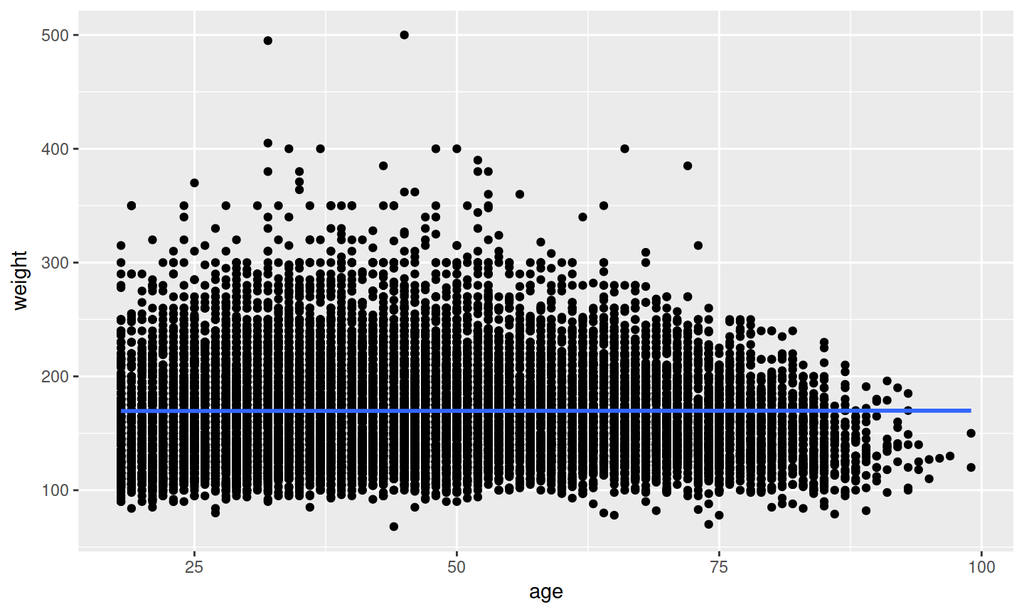

```r
cdc %>% qplot(age,weight, data=.) + geom_smooth(method="lm")
```

## Plotting

These can be plotted in 3-d graphs, but I find they are not very helpful

## Assumptions

- Independence
- Constant variance for *any combination* of the predictors

## An aside

Interaction terms aren’t treated in the text here, but I think this is a good place to talk about them

## Reminder

```r
cdc %>% lm(height~exerany+smoke100, data=.) %>% summary()
```

```
##
## Call:
## lm(formula = height ~ exerany + smoke100, data = .)
##
## Residuals:
##      Min       1Q   Median       3Q      Max
## -19.8306  -3.1297  -0.1297   3.1694  25.8703
##
## Coefficients:
##             Estimate Std. Error t value Pr(>|t|)
## (Intercept) 66.03788    0.06418 1028.96   <2e-16 ***
## exerany      1.09182    0.06637   16.45   <2e-16 ***
## smoke100     0.70088    0.05789   12.11   <2e-16 ***
## ---
## Signif. codes:  0 '***' 0.001 '**' 0.01 '*' 0.05 '.' 0.1 ' ' 1
##
## Residual standard error: 4.085 on 19997 degrees of freedom
## Multiple R-squared:  0.01983,    Adjusted R-squared:  0.01973
## F-statistic: 202.3 on 2 and 19997 DF,  p-value: < 2.2e-16
```

## New Model

```r
cdc %>% lm(height~exerany*smoke100, data=.) %>% summary()
```

```
##
## Call:
## lm(formula = height ~ exerany * smoke100, data = .)
##
## Residuals:
##      Min       1Q   Median       3Q      Max
## -19.7775  -3.1754  -0.1754   3.1172  25.8246
##
## Coefficients:
##                  Estimate Std. Error t value Pr(>|t|)
## (Intercept)      65.89383    0.08099 813.585  < 2e-16 ***
## exerany           1.28157    0.09296  13.787  < 2e-16 ***
## smoke100          0.98899    0.11454   8.634  < 2e-16 ***
## exerany:smoke100 -0.38692    0.13274  -2.915  0.00356 **
## ---
## Signif. codes:  0 '***' 0.001 '**' 0.01 '*' 0.05 '.' 0.1 ' ' 1
##
## Residual standard error: 4.084 on 19996 degrees of freedom
## Multiple R-squared:  0.02025,    Adjusted R-squared:  0.0201
## F-statistic: 137.8 on 3 and 19996 DF,  p-value: < 2.2e-16
```

## Reminder

```r
cdc %>% lm(height~age+exerany, data=.) %>% summary()
```

```
##
## Call:
## lm(formula = height ~ age + exerany, data = .)
##
## Residuals:
##      Min       1Q   Median       3Q      Max
## -19.9016  -3.0774  -0.1793   3.1191  25.1816
##
## Coefficients:
##              Estimate Std. Error t value Pr(>|t|)
## (Intercept) 67.715867   0.098654   686.4   <2e-16 ***
## age         -0.027761   0.001682   -16.5   <2e-16 ***
## exerany      0.963094   0.066417    14.5   <2e-16 ***
## ---
## Signif. codes:  0 '***' 0.001 '**' 0.01 '*' 0.05 '.' 0.1 ' ' 1
##
## Residual standard error: 4.072 on 19997 degrees of freedom
## Multiple R-squared:  0.02591,    Adjusted R-squared:  0.02582
## F-statistic:   266 on 2 and 19997 DF,  p-value: < 2.2e-16
```

## New Model

```r
cdc %>% lm(height~age*exerany, data=.) %>% summary()
```

```
##
## Call:
## lm(formula = height ~ age * exerany, data = .)
##
## Residuals:
##      Min       1Q   Median       3Q      Max
## -19.9511  -3.0744  -0.2034   3.1106  25.1414
##
## Coefficients:
##              Estimate Std. Error t value Pr(>|t|)
## (Intercept) 67.322420   0.164587 409.040  < 2e-16 ***
## age         -0.019534   0.003228  -6.051 1.46e-09 ***
## exerany      1.491846   0.189110   7.889 3.21e-15 ***
## age:exerany -0.011294   0.003782  -2.986  0.00283 **
## ---
## Signif. codes:  0 '***' 0.001 '**' 0.01 '*' 0.05 '.' 0.1 ' ' 1
##
## Residual standard error: 4.072 on 19996 degrees of freedom
## Multiple R-squared:  0.02635,    Adjusted R-squared:  0.0262
## F-statistic: 180.4 on 3 and 19996 DF,  p-value: < 2.2e-16
```

## Reminder

```r
cdc %>% lm(height~age+weight, data=.) %>% summary()
```

```
##
## Call:
## lm(formula = height ~ age + weight, data = .)
##
## Residuals:
##      Min       1Q   Median       3Q      Max
## -17.4194  -2.2439   0.0798   2.3813  24.8586
##
## Coefficients:
##               Estimate Std. Error t value Pr(>|t|)
## (Intercept) 58.8429936  0.1217266  483.40   <2e-16 ***
## age         -0.0302560  0.0013950  -21.69   <2e-16 ***
## weight       0.0571860  0.0005984   95.57   <2e-16 ***
## ---
## Signif. codes:  0 '***' 0.001 '**' 0.01 '*' 0.05 '.' 0.1 ' ' 1
##
## Residual standard error: 3.392 on 19997 degrees of freedom
## Multiple R-squared:  0.3243, Adjusted R-squared:  0.3242
## F-statistic:  4798 on 2 and 19997 DF,  p-value: < 2.2e-16
```

## New Model

```r
cdc %>% lm(height~age*weight, data=.) %>% summary()
```

```
##
## Call:
## lm(formula = height ~ age * weight, data = .)
##
## Residuals:
##      Min       1Q   Median       3Q      Max
## -17.4180  -2.2441   0.0849   2.3803  24.8684
##
## Coefficients:
##               Estimate Std. Error t value Pr(>|t|)
## (Intercept)  5.916e+01  2.961e-01 199.788  < 2e-16 ***
## age         -3.750e-02  6.321e-03  -5.933 3.03e-09 ***
## weight       5.523e-02  1.765e-03  31.291  < 2e-16 ***
## age:weight   4.450e-05  3.787e-05   1.175     0.24
## ---
## Signif. codes:  0 '***' 0.001 '**' 0.01 '*' 0.05 '.' 0.1 ' ' 1
##
## Residual standard error: 3.392 on 19996 degrees of freedom
## Multiple R-squared:  0.3243, Adjusted R-squared:  0.3242
## F-statistic:  3199 on 3 and 19996 DF,  p-value: < 2.2e-16
```

## Quick question

Why did I distinguish between predictors and explanatory variables earlier in the course?

## Try some

Use the imdb movies dataset on the website to create a multiple regression model - you pick the predictors and response variables

## Assessing Model Fit (3.2)

## Hypothesis Tests

How do we set up hypothesis tests for multiple regression?

Note: What do we do with a predictor that isn’t statistically significant? How do we find “the best model”?

## t-test

The t-test has \(n-k-1\) degrees of freedom when there are \(k\) predictors. Why does this make sense?

## Confidence intervals

\(\hat{\beta_i} \pm t^* SE_{\hat{\beta_i}}\)

## ANOVA tables

- One table for the model
- \(SSModel = \sum (\hat{y}-\bar{y})^2\)
- \(SSE = \sum (y-\hat{y})^2\)
- \(SSTotal = \sum (y - \bar{y})^2\)

## ANOVA table

Model is all the lines up to the residuals

```r
cdc %>% lm(height~age*exerany, data=.) %>% anova()
```

```
## Analysis of Variance Table
##
## Response: height
##                Df Sum Sq Mean Sq  F value    Pr(>F)
## age             1   5335  5335.1 321.8262 < 2.2e-16 ***
## exerany         1   3487  3487.1 210.3528 < 2.2e-16 ***
## age:exerany     1    148   147.8   8.9171  0.002829 **
## Residuals   19996 331483    16.6
## ---
## Signif. codes:  0 '***' 0.001 '**' 0.01 '*' 0.05 '.' 0.1 ' ' 1
```

This looks different than the book…

## Getting the book results…

```r
NFL <- read_csv("http://stat2.org/datasets/NFL2007Standings.csv")
NFL %>% lm(WinPct~PointsFor+PointsAgainst, data=.) %>% anova()
```

```
## Analysis of Variance Table
##
## Response: WinPct
##               Df  Sum Sq Mean Sq F value    Pr(>F)
## PointsFor      1 1.01724 1.01724 190.983 2.727e-14 ***
## PointsAgainst  1 0.16411 0.16411  30.812 5.496e-06 ***
## Residuals     29 0.15446 0.00533
## ---
## Signif. codes:  0 '***' 0.001 '**' 0.01 '*' 0.05 '.' 0.1 ' ' 1
```

```r
NFL %>% lm(WinPct~PointsFor+PointsAgainst, data=.) %>% summary()
```

```
##
## Call:
## lm(formula = WinPct ~ PointsFor + PointsAgainst, data = .)
##
## Residuals:
##      Min       1Q   Median       3Q      Max
## -0.15857 -0.05318 -0.01259  0.07360  0.12962
##
## Coefficients:
##                 Estimate Std. Error t value Pr(>|t|)
## (Intercept)    0.4172230  0.1394480   2.992  0.00561 **
## PointsFor      0.0017662  0.0001870   9.445 2.37e-10 ***
## PointsAgainst -0.0015268  0.0002751  -5.551 5.50e-06 ***
## ---
## Signif. codes:  0 '***' 0.001 '**' 0.01 '*' 0.05 '.' 0.1 ' ' 1
##
## Residual standard error: 0.07298 on 29 degrees of freedom
## Multiple R-squared:  0.8844, Adjusted R-squared:  0.8764
## F-statistic: 110.9 on 2 and 29 DF,  p-value: 2.598e-14
```

## Hang on to your seats

```r
forFirst <- NFL %>% lm(WinPct~PointsFor+PointsAgainst, data=.)
againstFirst <- NFL %>% lm(WinPct~PointsAgainst+PointsFor, data=.)
```

What’s the difference?

## Sumamries

```r
summary(forFirst)
```

```
##
## Call:
## lm(formula = WinPct ~ PointsFor + PointsAgainst, data = .)
##
## Residuals:
##      Min       1Q   Median       3Q      Max
## -0.15857 -0.05318 -0.01259  0.07360  0.12962
##
## Coefficients:
##                 Estimate Std. Error t value Pr(>|t|)
## (Intercept)    0.4172230  0.1394480   2.992  0.00561 **
## PointsFor      0.0017662  0.0001870   9.445 2.37e-10 ***
## PointsAgainst -0.0015268  0.0002751  -5.551 5.50e-06 ***
## ---
## Signif. codes:  0 '***' 0.001 '**' 0.01 '*' 0.05 '.' 0.1 ' ' 1
##
## Residual standard error: 0.07298 on 29 degrees of freedom
## Multiple R-squared:  0.8844, Adjusted R-squared:  0.8764
## F-statistic: 110.9 on 2 and 29 DF,  p-value: 2.598e-14
```

```r
summary(againstFirst)
```

```
##
## Call:
## lm(formula = WinPct ~ PointsAgainst + PointsFor, data = .)
##
## Residuals:
##      Min       1Q   Median       3Q      Max
## -0.15857 -0.05318 -0.01259  0.07360  0.12962
##
## Coefficients:
##                 Estimate Std. Error t value Pr(>|t|)
## (Intercept)    0.4172230  0.1394480   2.992  0.00561 **
## PointsAgainst -0.0015268  0.0002751  -5.551 5.50e-06 ***
## PointsFor      0.0017662  0.0001870   9.445 2.37e-10 ***
## ---
## Signif. codes:  0 '***' 0.001 '**' 0.01 '*' 0.05 '.' 0.1 ' ' 1
##
## Residual standard error: 0.07298 on 29 degrees of freedom
## Multiple R-squared:  0.8844, Adjusted R-squared:  0.8764
## F-statistic: 110.9 on 2 and 29 DF,  p-value: 2.598e-14
```

## ANOVA tables

```r
anova(forFirst)
```

```
## Analysis of Variance Table
##
## Response: WinPct
##               Df  Sum Sq Mean Sq F value    Pr(>F)
## PointsFor      1 1.01724 1.01724 190.983 2.727e-14 ***
## PointsAgainst  1 0.16411 0.16411  30.812 5.496e-06 ***
## Residuals     29 0.15446 0.00533
## ---
## Signif. codes:  0 '***' 0.001 '**' 0.01 '*' 0.05 '.' 0.1 ' ' 1
```

```r
anova(againstFirst)
```

```
## Analysis of Variance Table
##
## Response: WinPct
##               Df  Sum Sq Mean Sq F value    Pr(>F)
## PointsAgainst  1 0.70618 0.70618 132.583 2.455e-12 ***
## PointsFor      1 0.47517 0.47517  89.212 2.370e-10 ***
## Residuals     29 0.15446 0.00533
## ---
## Signif. codes:  0 '***' 0.001 '**' 0.01 '*' 0.05 '.' 0.1 ' ' 1
```

## Meet the new \(R^2\), same as the old \(R^2\)

\(R^2\) is the coefficient of determiniation (this *was* the square of the correlation coefficient)

\[R^2 = \frac{variability \ explained \ by \ model}{total \ variability \ in \ y} = \frac{SSModel}{SSTotal} = 1 - \frac{SSE}{SSTotal}\]

What is our correlation coefficient now?

```r
summary(forFirst)
```

```
##
## Call:
## lm(formula = WinPct ~ PointsFor + PointsAgainst, data = .)
##
## Residuals:
##      Min       1Q   Median       3Q      Max
## -0.15857 -0.05318 -0.01259  0.07360  0.12962
##
## Coefficients:
##                 Estimate Std. Error t value Pr(>|t|)
## (Intercept)    0.4172230  0.1394480   2.992  0.00561 **
## PointsFor      0.0017662  0.0001870   9.445 2.37e-10 ***
## PointsAgainst -0.0015268  0.0002751  -5.551 5.50e-06 ***
## ---
## Signif. codes:  0 '***' 0.001 '**' 0.01 '*' 0.05 '.' 0.1 ' ' 1
##
## Residual standard error: 0.07298 on 29 degrees of freedom
## Multiple R-squared:  0.8844, Adjusted R-squared:  0.8764
## F-statistic: 110.9 on 2 and 29 DF,  p-value: 2.598e-14
```

## Where does it come from?

```r
r <- cor(forFirst$fitted.values, NFL$WinPct)
r
```

```
## [1] 0.9404083
```

```r
r^2
```

```
## [1] 0.8843678
```

## Adjusted \(R^2\)

\[R^2_{adj} = 1-\frac{SSE/(n-k-1)}{SSTotal/(n-1)} = 1-\frac{\hat{\sigma_\epsilon}}{S^2_Y}\]

## Comparing Regression Lines (3.3)

## New stuff?

Not really - we’ve already been doing this

An *indicator variable* uses two values to denote group membership (usually 0 and 1)

How do we compare the slopes of two different groups when we have an indicator variable? How do we tell whether they are statistically significantly different?

## New Variables (3.4)

## Types of models

- Interaction terms (done)
- Polynomial regression

## Using the Diamonds dataset

- Predict total price from carats
- Create a new variable - carats squared
  - Now predict price from carats and carats squared

WAIT - WHY ARE WE MAKING A LINEAR MODEL AND GETTING A QUADRATIC???

## Notes on making new variables

- You can either define new variables (e.g. mutate()), or
- You can use I() to just define a new variable inside a model, but then the new variable is lost

Either:

`Diamonds %>% lm(TotalPrice~Caret+Caret2)` or

`Diamonds %>% lm(TotalPrice~Caret+I(Caret^2)`

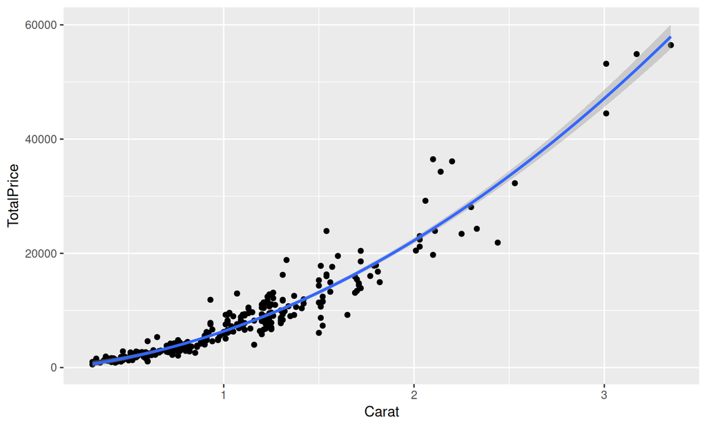

```r
Diamonds %>% ggplot(aes(x=Carat, y=TotalPrice))+geom_point()+
  geom_smooth(method="lm", formula=y~x+I(x^2))
```

## A side note on factors (4.4, my take)

- 4.4 recommends using separate indicator variables for each level of a categorical/factor variable.

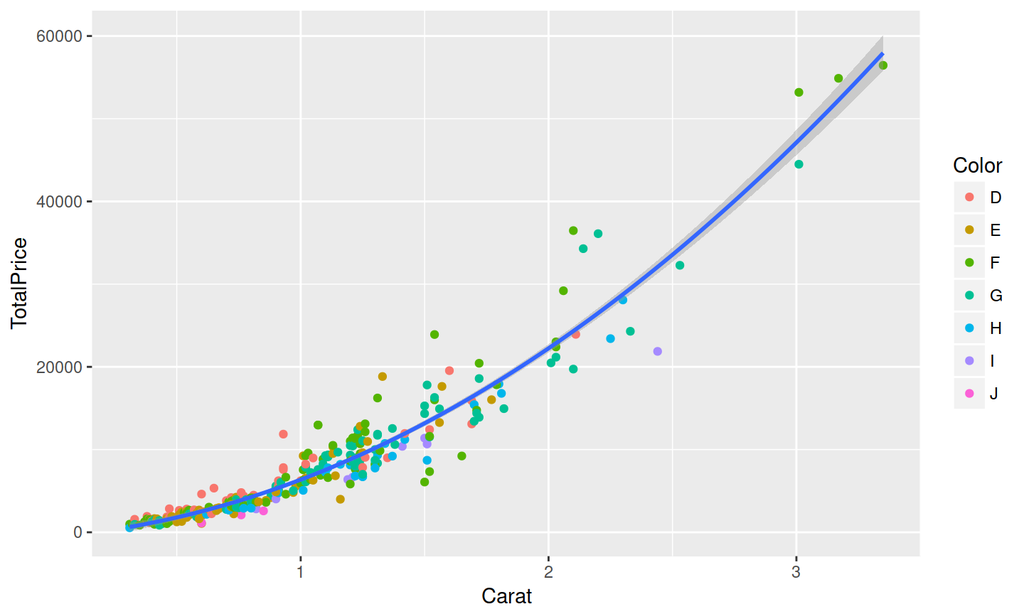

```r
Diamonds %>% ggplot(aes(x=Carat, y=TotalPrice))+geom_point(aes(color=Color))+
  geom_smooth(method="lm", formula=y~x+I(x^2))
```

## What’s the difference?

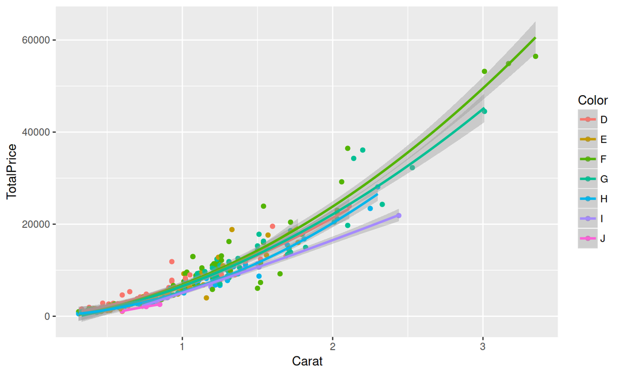

```r
Diamonds %>% ggplot(aes(x=Carat, y=TotalPrice, color=Color))+geom_point()+
  geom_smooth(method="lm", formula=y~x+I(x^2))
```

## Getting the equations

Create a regression predicting price from carat and color (not carat\(^2\)) yet, and plot it